# HW1

Lowson Li, R08323023

# 1 Load packages

```r
library(tidyverse)
library(tidygraph)
library(igraph)
library(visNetwork)
```

# 2 Import data

```r
library(readr)
class <- read_csv("../Data/class.csv", col_names = FALSE)
```

# 3 Q1

Generate the network (with 12 nodes) with the given edge set, complete the corresponding analysis and visualization tasks.

Edge set: 1 and 2, 1 and 3, 1 and 4, 1 and 8, 1 and 10, 1 and 11, 1 and 12; 2 and 3, 2 and 4, 2 and 5, 2 and 6; 3 and 5, 3 and 6; 4 and 7, 4 and 9, 4 and 10, 4 and 12; 5 and 9, 5 and 11; 6 and 12; 7 and 11; 8 and 12; 9 and 10; 11 and 12;

1. Report the adjacency matrix, and plot this network with labels.
2. Find the node(s) with maximum degree, what’s the maximum degree value? And find the node(s) with maximum betweenness, what’s the maximum betweenness value?

## 3.1 Create node list

```r
node_list <- tibble(id = 1:12)
```

## 3.2 Create edge list

```r
edge_list <- tibble(from = c(rep(1, 7), rep(2, 4), rep(3, 2), rep(4, 4), rep(5, 2), 6:9, 11), to = c(2, 3, 4, 8, 10, 11, 12, 3, 4, 5, 6, 5, 6, 7, 9, 10, 12, 9, 11, 12, 11, 12, 10, 12))
```

## 3.3 Adjancency matrix

```r
tbl_graph(nodes = node_list, edges = edge_list, directed = FALSE) %>%
  igraph::get.adjacency()
```

```
12 x 12 sparse Matrix of class "dgCMatrix"

 [1,] . 1 1 1 . . . 1 . 1 1 1
 [2,] 1 . 1 1 1 1 . . . . . .
 [3,] 1 1 . . 1 1 . . . . . .
 [4,] 1 1 . . . . 1 . 1 1 . 1
 [5,] . 1 1 . . . . . 1 . 1 .
 [6,] . 1 1 . . . . . . . . 1
 [7,] . . . 1 . . . . . . 1 .
 [8,] 1 . . . . . . . . . . 1
 [9,] . . . 1 1 . . . . 1 . .
[10,] 1 . . 1 . . . . 1 . . .
[11,] 1 . . . 1 . 1 . . . . 1
[12,] 1 . . 1 . 1 . 1 . . 1 .
```

## 3.4 Plot the networks

### 3.4.1 igraph

This will plot original igraph.

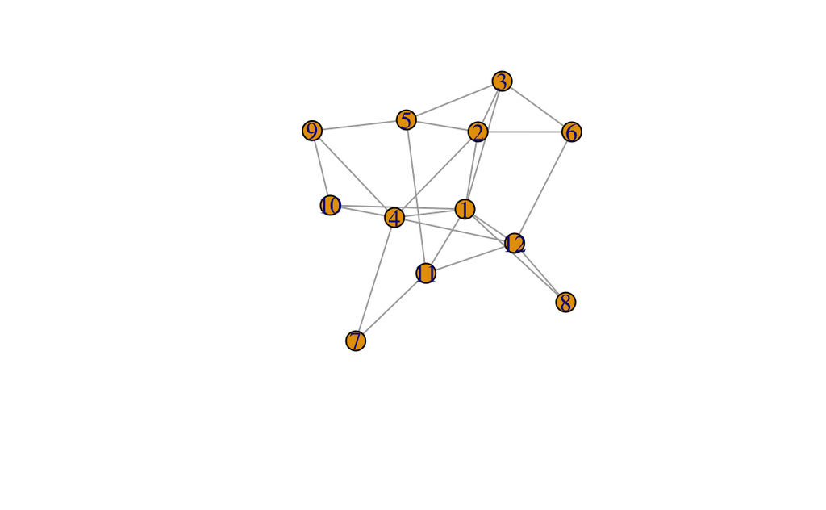

```r
g <- tbl_graph(nodes = node_list, edges = edge_list, directed = FALSE) # save graph named "g"
g %>%
  plot()
```

### 3.4.2 visNetwork

By `visNetwork`, we can plot interactive network.

```r
 g %>%
  visIgraph()
```

[interactive chart not shown]

## 3.5 Descriptive analysis

### 3.5.1 Degree

```r
g %>%
  mutate(degree = tidygraph::centrality_degree()) %>%
  arrange(desc(degree))
```

```
# A tbl_graph: 12 nodes and 24 edges
#
# An undirected simple graph with 1 component
#
# Node Data: 12 x 2 (active)
     id degree
  <int>  <dbl>
1     1      7
2     4      6
3     2      5
4    12      5
5     3      4
6     5      4
# … with 6 more rows
#
# Edge Data: 24 x 2
   from    to
  <int> <int>
1     1     3
2     1     5
3     1     2
# … with 21 more rows
```

We can found that the node 1 has the maximum degree 7.

### 3.5.2 Betweenness

```r
g %>%
  mutate(betweenness = tidygraph::centrality_betweenness()) %>%
  arrange(desc(betweenness))
```

```
# A tbl_graph: 12 nodes and 24 edges
#
# An undirected simple graph with 1 component
#
# Node Data: 12 x 2 (active)
     id betweenness
  <int>       <dbl>
1     1       12.7
2     4       10.6
3    12        6.57
4    11        5.17
5     2        4.40
6     5        4.25
# … with 6 more rows
#
# Edge Data: 24 x 2
   from    to
  <int> <int>
1     1     5
2     1     7
3     1     2
# … with 21 more rows
```

We can found that the node 1 has the maximum betweenness 12.7.

# 4 Q2

Import the friendship network in a class represented by an adjacency matrix “class” into R:

1. What is the highest page rank value among nodes?
2. What is the size of the largest component in this network?
3. What is the global clustering coefficient and assortivity of outdegree in this network?

```r
# data has imported, change it into igraph networks
g_class <- class %>%
  as.matrix() %>%
  igraph::graph.adjacency(mode = "directed", weighted = NULL)
# though the graph seems undirected, using directed mode will help count outdegree
g_class %>%
  visNetwork::visIgraph()
```

[interactive chart not shown]

```r
# use visIgraph function from visNetwork package for interactive view of network
```

## 4.1 Page rank

```r
g_class %>%
  igraph::page.rank()
```

```
$vector
        X1         X2         X3         X4         X5         X6
0.01886792 0.01886792 0.01886792 0.01886792 0.01886792 0.01886792
        X7         X8         X9        X10        X11        X12
0.01886792 0.01886792 0.01886792 0.01886792 0.01886792 0.01886792
       X13        X14        X15        X16        X17        X18
0.01886792 0.01886792 0.01886792 0.01886792 0.01886792 0.01886792
       X19        X20        X21        X22        X23        X24
0.01886792 0.01886792 0.01886792 0.01886792 0.01886792 0.01886792
       X25        X26        X27        X28        X29        X30
0.01886792 0.01886792 0.01886792 0.01886792 0.01886792 0.01886792
       X31        X32        X33        X34        X35        X36
0.01886792 0.01886792 0.01886792 0.01886792 0.01886792 0.01886792
       X37        X38        X39        X40        X41        X42
0.01886792 0.01886792 0.01886792 0.01886792 0.01886792 0.01886792
       X43        X44        X45        X46        X47        X48
0.01886792 0.01886792 0.01886792 0.01886792 0.01886792 0.01886792
       X49        X50        X51        X52        X53
0.01886792 0.01886792 0.01886792 0.01886792 0.01886792

$value
[1] 1

$options
NULL
```

All of the nodes have the same Page rank scores 0.01886792 since they all point to each other.

## 4.2 Largest component

```r
g_class %>%
  igraph::components() %>%
  .$csize %>%
  sort(decreasing = TRUE)
```

```
[1] 11 11 10 10  7  4
```

The size of the largest component in this network is 11.

## 4.3 Global clustering coefficient

```r
g_class %>%
  igraph::transitivity(type = "global")
```

```
[1] 1
```

In `igraph`, the global clustering coefficient is call transitivity. The global clustering coefficient of the class network is 1.

## 4.4 Assortativity of outdegree

```r
g_class %>%
  igraph::assortativity.degree()
```

```
[1] 1
```

Since the grapg is symmertric, the ourdegree is qual to the indegree for each node. The assortativity of outdegree is 1.

# 5 References

- [Introduction to Network Analysis with R](https://www.jessesadler.com/post/network-analysis-with-r/)
- [Introducing tidygraph](https://www.data-imaginist.com/2017/introducing-tidygraph/)
- [Introduction to tidygraph & ggraph](https://www.rpubs.com/Steven_Surya/tidygraph-ggraph)
- [Convert a graph to an adjacency matrix or an edge list](http://cneurocvs.rmki.kfki.hu/igraph/doc/R/conversion.html)
- [Tidygraph](http://users.dimi.uniud.it/~massimo.franceschet/ns/syllabus/make/tidygraph/tidygraph.html)
- [visNetwork](https://datastorm-open.github.io/visNetwork/)
- [Social network analysis with R: Descriptive analysis](http://pablobarbera.com/big-data-upf/html/02b-networks-descriptive-analysis.html)
- [Betweenness centrality](https://en.wikipedia.org/wiki/Betweenness_centrality)
- [Import a Matrix as an igraph Network](https://rpubs.com/pjmurphy/310459)
- [Clustering coefficient](https://en.wikipedia.org/wiki/Clustering_coefficient)
- Assortativity